# Appendix D - R Programming Fundamentals

Bill Cresko

# Appendix D: R Programming Fundamentals

## Overview

**Pre-requisite Material**

This appendix provides a comprehensive introduction to the R programming language. R is the primary tool used throughout this course for statistical analysis and data visualization. See also Week 1 of the main lectures for additional R and RStudio basics.

# Why R?

## Why Use R?

- Good general scripting tool for statistics and mathematics
- Powerful, flexible, and free
- Runs on all computer platforms
- New enhancements coming out all the time
- Superb data management & graphics capabilities
- Reproducibility — keep your scripts to see exactly what was done
- You can write your own functions
- Lots of online help available
- Can use a nice GUI front end such as `RStudio`
- Can embed your `R` analyses in dynamic, polished files using `Quarto Markdown`

## R Scripts and Quarto Markdown

- Often we want to write scripts that can just be run — `R scripts`
- We can also embed code in Quarto Markdown files for more annotations
- This improves interpretability and reproducibility
- You can insert `R code chunks` into `Quarto Markdown` documents
- A series of R commands that will be executed
- Can add comments using hashtags `#`
- Can have pipes (`|>`) to connect one step to the next

# R Basics

## Basic Math in R

- Output
- Code
- Interpretation

```
[1] 16
```

```
[1] 16
```

```r
4 * 4
(4 + 3 * 2^2)
```

- Commands can be submitted through the terminal, console, or scripts
- R follows the normal priority of mathematical evaluation (PEMDAS)
- Parentheses control order of operations just as in algebra

## Assigning Variables

- Output
- Code
- Interpretation

```
[1] 6
```

```
[1] 4
```

```r
x <- 2
x * 3
y <- x * 3
y - 2
```

- Variables are assigned values using the `<-` operator
- Variable names must begin with a letter
- R is case sensitive (`x` and `X` are different)
- The result of calculations can be assigned to new variables
- Names like `3y <- 3` or `3*y <- 3` will not work

## Arithmetic Operations and Functions

- Output
- Code
- Interpretation

```
[1] 67
```

```
[1] 69022864
```

```r
# Common math functions
x + 2
x^2
log(x)    # natural log (built-in function)
sqrt(x)

# Assigning results
y <- 67
print(y)
x <- 124
z <- (x * y)^2
print(z)
```

- `log` is a built-in function — the object goes in parentheses
- Functions can take arguments that modify behavior (e.g., `log(x, base = 10)`)
- The outcome of calculations can be assigned to new variables
- Use `print()` to display values explicitly

# Data Types and Structures

## Strings

- Output
- Code
- Interpretation

```
[1] "I Love"
```

```
[1] "Bioengineering"
```

```
[1] "I Love"         "Bioengineering"
```

```r
x <- "I Love"
print(x)
y <- "Bioengineering"
print(y)
z <- c(x, y)    # c stands for concatenate
print(z)
```

- Characters need to be set off by quotation marks
- The `c()` function stands for `concatenate`
- Reusing variable names overwrites previous assignments
- Good practice: use descriptive, unique names for each variable

## Vectors

- Output
- Code
- Interpretation

```
 [1]  2  3  4  2  1  2  4  5 10  8  9
```

```
 [1]   4   9  16   4   1   4  16  25 100  64  81
```

```r
# Create a vector with c()
x <- c(2, 3, 4, 2, 1, 2, 4, 5, 10, 8, 9)
print(x)

# Operations work element-wise
y <- x^2
print(y)

# Plot vectors
plot(x, y)
```

- R thinks in terms of **vectors** (a list of values)
- Vectors can be assigned directly using the `c()` function
- Mathematical operations on vectors work element-wise
- Writing programs with vectors in mind will simplify most things

## Types of Vectors

- Types
- Special Values

| Type | Description | Example |
| --- | --- | --- |
| `int` | Integers | `1L, 2L, 3L` |
| `dbl` | Doubles (real numbers) | `3.14, 2.718` |
| `chr` | Character strings | `"hello", "DNA"` |
| `lgl` | Logical (TRUE/FALSE) | `TRUE, FALSE, NA` |
| `fctr` | Factors (categorical variables) | `factor(c("a","b","a"))` |
| `dttm` | Date-times | `Sys.time()` |
| `date` | Dates | `Sys.Date()` |

- Logical vectors can take: `FALSE`, `TRUE`, or `NA` (not available)
- Doubles have four special values: `NA`, `NaN` (not a number), `Inf`, `-Inf`
- Integer and double vectors are collectively known as **numeric** vectors
- In R, numbers are doubles by default

## Basic Statistics on Vectors

- Output
- Code
- Interpretation

```
Mean: 4.545455
```

```
Median: 4
```

```
Variance: 9.672727
```

```
SD: 3.110101
```

```
Sum: 50
```

```
Length: 11
```

```r
mean(x)
median(x)
var(x)
sd(x)        # standard deviation
log(x)
sqrt(x)
sum(x)
length(x)
sample(x, replace = TRUE)  # random sample with replacement
```

- Many built-in functions operate on vectors
- `sample()` has an argument `replace = T` — arguments modify function behavior
- There are many arguments for each function, some of which are defaults
- Use `?function_name` to see the help page for any function

## Creating Vectors with Sequences

- Output
- Code
- Interpretation

```
 [1] 0.0 0.1 0.2 0.3 0.4 0.5 0.6 0.7 0.8 0.9 1.0 1.1 1.2 1.3 1.4 1.5 1.6 1.7 1.8
[20] 1.9
```

```
 [1] 10.0  9.9  9.8  9.7  9.6  9.5  9.4  9.3  9.2  9.1  9.0  8.9  8.8  8.7  8.6
[16]  8.5  8.4  8.3  8.2  8.1
```

```r
# Ascending sequence
seq_1 <- seq(0.0, 10.0, by = 0.1)
print(seq_1)

# Descending sequence
seq_2 <- seq(10.0, 0.0, by = -0.1)
print(seq_2)

# Element-wise operations
seq_square <- (seq_2)^2
print(seq_square)
```

- `seq()` creates sequences with a specified start, end, and step size
- The three arguments in the parentheses are: start, end, and step
- Operations on sequences work element-wise, just like simple vectors

## Getting Help in R

- Methods
- Interpretation

```r
help(mean)           # Open help page
?mean                # Same as help()
example(mean)        # Show examples
help.search("mean")  # Search help pages
apropos("mean")      # Find functions with "mean" in name
args(mean)           # Show function arguments
```

- Help pages exist for all functions explaining parameters and usage
- Function calls have a simple structure: function name + parentheses + parameters
- The `example()` function is especially useful for seeing how functions work
- When in doubt, check the help page!

# Sampling from Distributions

## Drawing Random Samples

- Output
- Code
- Interpretation

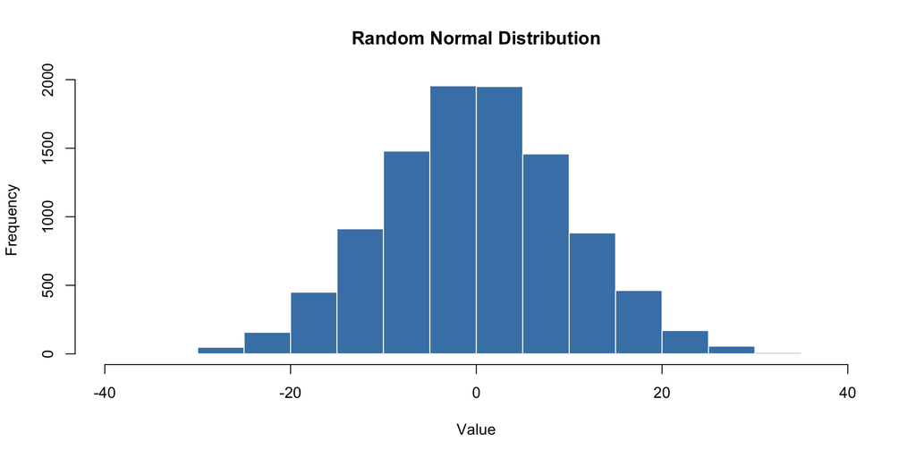

```r
# Draw from normal distribution
x <- rnorm(10000, 0, 10)
hist(x)

# Draw uniform random integers
y <- sample(1:10000, 10000, replace = TRUE)

# Combine and plot
xy <- cbind(x, y)
plot(x, y)
```

- `rnorm(n, mean, sd)` draws `n` random values from a normal distribution
- `sample()` draws random values with equal probability
- `cbind()` binds columns together into a matrix
- These tools are fundamental for simulation and statistical analysis

## Overlaying Density Curves

- Output
- Code
- Interpretation

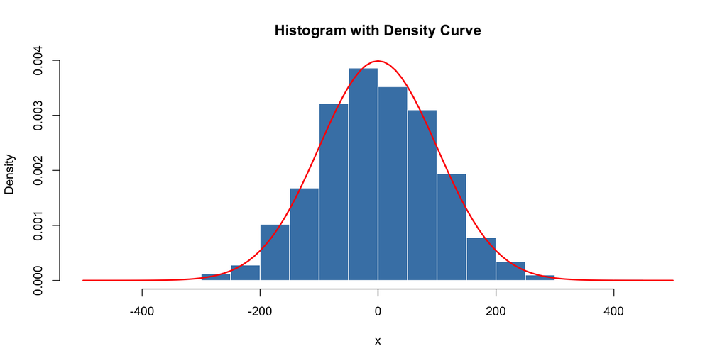

```r
x <- rnorm(1000, 0, 100)
hist(x, xlim = c(-500, 500), probability = TRUE)
curve(dnorm(x, 0, 100), xlim = c(-500, 500), add = TRUE, col = 'red', lwd = 2)
```

- `dnorm()` generates the probability density function
- `curve()` plots a function — `add = TRUE` overlays on existing plot
- The red curve shows the theoretical distribution we sampled from
- Histograms with density overlays help verify sampling behavior

# Data Frames

## Creating Data Frames

- Output
- Code
- Interpretation

```
         hydrogel_concentration compression conductivity
Sample_1                    low         3.4          0.0
Sample_2                   high         3.4          9.2
Sample_3                   high         8.4          3.8
Sample_4                   high         3.0          5.0
Sample_5                 medium         5.6          5.6
Sample_6                 medium         8.1          4.1
Sample_7                 medium         8.3          7.1
Sample_8                    low         4.5          5.3
```

```r
# Set up vectors as columns
hydrogel_concentration <- factor(c("low", "high", "high", "high",
                                    "medium", "medium", "medium", "low"))
compression <- c(3.4, 3.4, 8.4, 3, 5.6, 8.1, 8.3, 4.5)
conductivity <- c(0, 9.2, 3.8, 5, 5.6, 4.1, 7.1, 5.3)

# Create data frame
mydata <- data.frame(hydrogel_concentration, compression, conductivity)
row.names(mydata) <- c("Sample_1", "Sample_2", "Sample_3", "Sample_4",
                        "Sample_5", "Sample_6", "Sample_7", "Sample_8")
print(mydata)
```

- Data frames are the primary data structure for tabular data in R
- Vectors become columns when combined with `data.frame()`
- `factor()` creates categorical variables with fixed levels
- `row.names()` assigns labels to each row

## Reading and Writing Data

- Reading
- Writing
- Interpretation

```r
# Comma-separated files
YourFile <- read.table('yourfile.csv', header = TRUE, row.names = 1, sep = ',')
# OR use the convenience function:
YourFile <- read.csv('yourfile.csv')

# Tab-separated files
YourFile <- read.table('yourfile.txt', header = TRUE, row.names = 1, sep = '\t')

# Tidyverse versions (return tibbles)
YourFile <- read_csv('yourfile.csv')
YourFile <- read_tsv('yourfile.txt')

# Excel files
library(readxl)
YourFile <- read_excel('yourfile.xlsx')
```

```r
# Write to CSV
write.table(YourFile, "yourfile.csv", quote = FALSE, row.names = TRUE, sep = ",")
# OR:
write.csv(YourFile, "yourfile.csv")

# Write to TSV
write.table(YourFile, "yourfile.txt", quote = FALSE, row.names = TRUE, sep = "\t")

# Tidyverse version
write_csv(YourFile, "yourfile.csv")
```

- `header = TRUE` indicates the first row contains column names
- `row.names = 1` indicates the first column contains row names
- `sep` specifies the delimiter (`,` for CSV, `\t` for TSV)
- The tidyverse `read_csv()` and `read_tsv()` functions return tibbles (enhanced data frames)

## Indexing Data Frames

- Output
- Code
- Interpretation

```
[1] 3.4 3.4 8.4 3.0 5.6 8.1 8.3 4.5
```

```
[1] 3.4 3.4 8.4 3.0 5.6 8.1 8.3 4.5
```

```
         hydrogel_concentration compression conductivity
Sample_2                   high         3.4          9.2
```

```r
# Access by column number
print(mydata[, 2])

# Access by column name (preferred)
print(mydata$compression)

# Access by row number
print(mydata[2, ])

# Access specific cell
print(mydata[2, 3])

# Subset based on condition
print(mydata$compression > 5)

# Plot two columns
plot(mydata$compression, mydata$conductivity)
```

- `[row, column]` notation accesses specific elements
- `$` notation accesses columns by name (preferred — more readable)
- Leaving a dimension empty selects all (e.g., `[, 2]` = all rows, column 2)
- Logical conditions return TRUE/FALSE vectors for subsetting

# Base R Visualization

## Basic Plotting

- Output
- Code
- Interpretation

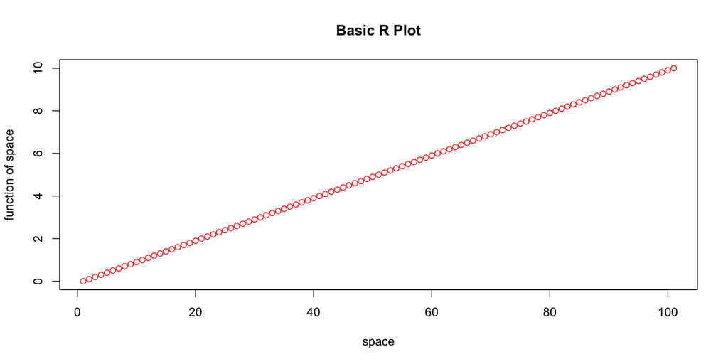

```r
seq_1 <- seq(0.0, 10.0, by = 0.1)
plot(seq_1,
     xlab = "space",
     ylab = "function of space",
     type = "p",        # "p" = points, "l" = lines, "b" = both
     col = "red",
     main = "Basic R Plot")
```

- `plot()` is the main high-level plotting function in base R
- Arguments like `xlab`, `ylab`, `col`, and `type` control appearance
- `type` options: `"p"` (points), `"l"` (lines), `"b"` (both), `"h"` (histogram-like)
- Most people use `ggplot2` for publication-quality graphics (see Week 2)

## Multi-Panel Figures

- Output
- Code
- Interpretation

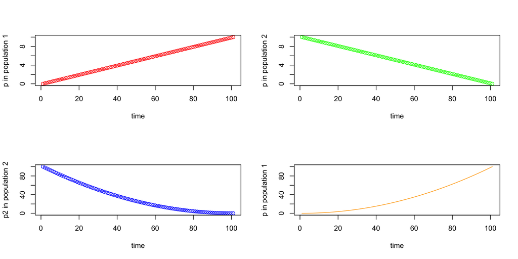

```r
par(mfrow = c(2, 2))  # 2 rows, 2 columns
plot(seq_1, xlab = "time", ylab = "p in pop 1", type = "p", col = 'red')
plot(seq_2, xlab = "time", ylab = "p in pop 2", type = "p", col = 'green')
plot(seq_square, xlab = "time", ylab = "p2 in pop 2", type = "p", col = 'blue')
plot(seq_1^2, xlab = "time", ylab = "p in pop 1", type = "l", col = 'orange')
```

- `par(mfrow = c(rows, cols))` sets up a multi-panel layout
- Subsequent `plot()` calls fill panels left-to-right, top-to-bottom
- This is useful for comparing related visualizations side by side

## Summary Statistics and Figures

- Output
- Code
- Interpretation

```
   Min. 1st Qu.  Median    Mean 3rd Qu.    Max.
  3.000   3.400   5.050   5.588   8.150   8.400
```

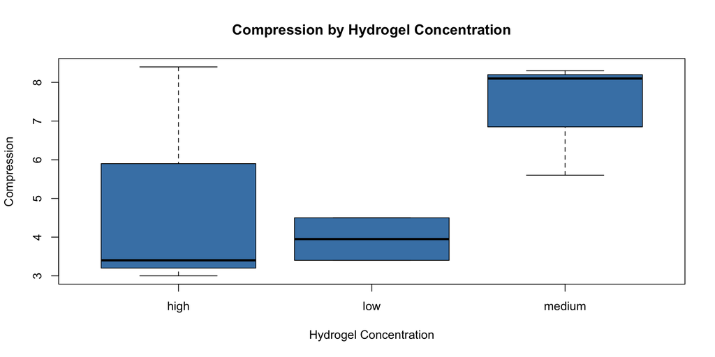

```r
# Summary statistics
summary(mydata$compression)

# Histogram
hist(mydata$compression)

# Boxplot by group
boxplot(compression ~ hydrogel_concentration, data = mydata,
        col = "steelblue",
        ylab = "Compression",
        xlab = "Hydrogel Concentration",
        main = "Compression by Hydrogel Concentration")
```

- `summary()` provides min, max, quartiles, mean, and median
- The formula notation `y ~ x` means “y grouped by x”
- Boxplots show median, IQR, and potential outliers
- These are quick exploratory tools — use `ggplot2` for publication graphics

## Tidy Data Principles

**Rules of Thumb for Data Organization**

- Store data in nonproprietary formats (plain ASCII text / flat files)
- Leave an uncorrected original file when doing analyses
- Use descriptive names for your data files and variables
- Include a header line with descriptive variable names
- Maintain effective metadata about the data (data dictionary)
- When you add observations, add rows
- When you add variables, add columns
- A column of data should contain only one data type

## Types of Data

| Categorical |  | Quantitative |  |
| --- | --- | --- | --- |
| Ordinal | Nominal | Ratio | Interval |
| small, medium, large | apples, oranges | kilograms, dollars | temperature, calendar year |
| ordered character | character | numeric | integer |

`Factor` is a special type of character variable that R uses to represent categorical variables with fixed possible values.